# P8451 Assignment 1

2023-01-24

## 1. Descriptive statistics

### Reading in the data

First, let’s read in the dataset.

```r
bc_data = read_csv("./bcdata_Assignment1.csv")
```

We can see that the `bc_data` table contains 116 observations of 10 variables.

### Summary table

We will construct a table providing summaries of the mean, median, minimum value, and maximum value of each variable in the dataset.

```r
summary(bc_data) %>% knitr::kable()
```

|  | Age | BMI | Glucose | Insulin | HOMA | Leptin | Adiponectin | Resistin | MCP.1 | Classification |
| --- | --- | --- | --- | --- | --- | --- | --- | --- | --- | --- |
|  | Min. :24.0 | Min. :18.37 | Min. : 60.00 | Min. : 2.432 | Min. : 0.4674 | Min. : 4.311 | Min. : 1.656 | Min. : 3.210 | Min. : 45.84 | Min. :1.000 |
|  | 1st Qu.:45.0 | 1st Qu.:22.97 | 1st Qu.: 85.75 | 1st Qu.: 4.359 | 1st Qu.: 0.9180 | 1st Qu.:12.314 | 1st Qu.: 5.474 | 1st Qu.: 6.882 | 1st Qu.: 269.98 | 1st Qu.:1.000 |
|  | Median :56.0 | Median :27.66 | Median : 92.00 | Median : 5.925 | Median : 1.3809 | Median :20.271 | Median : 8.353 | Median :10.828 | Median : 471.32 | Median :2.000 |
|  | Mean :57.3 | Mean :27.58 | Mean : 97.79 | Mean :10.012 | Mean : 2.6950 | Mean :26.615 | Mean :10.181 | Mean :14.726 | Mean : 534.65 | Mean :1.552 |
|  | 3rd Qu.:71.0 | 3rd Qu.:31.24 | 3rd Qu.:102.00 | 3rd Qu.:11.189 | 3rd Qu.: 2.8578 | 3rd Qu.:37.378 | 3rd Qu.:11.816 | 3rd Qu.:17.755 | 3rd Qu.: 700.09 | 3rd Qu.:2.000 |
|  | Max. :89.0 | Max. :38.58 | Max. :201.00 | Max. :58.460 | Max. :25.0503 | Max. :90.280 | Max. :38.040 | Max. :82.100 | Max. :1698.44 | Max. :2.000 |

## 2. Recoding BMI

The code chunk below creates a new variable, `BMI_cat`, which recodes BMI into 7 categories as defined by the WHO.

```r
bc_data = bc_data %>%
  mutate(BMI_cat = as.factor(case_when(BMI < 16.5 ~ "Severely underweight",
                             BMI < 18.5 & BMI >= 16.5 ~ "Underweight",
                             BMI < 25 & BMI >= 18.5 ~ "Normal weight",
                             BMI < 30 & BMI >= 25 ~ "Overweight",
                             BMI < 35 & BMI >= 30 ~ "Obesity class I",
                             BMI < 40 & BMI >= 35 ~ "Obesity class II",
                             BMI >= 40 ~ "Obesity class III"
                             )))
```

## 3. Plotting breast cancer rates across BMI categories

Next, we will create a bar chart showing the proportion of breast cancer cases and controls within each BMI category. For interpretability, we will format the `Classification` variable into a factor variable such that 1 = Control and 2 = Case.

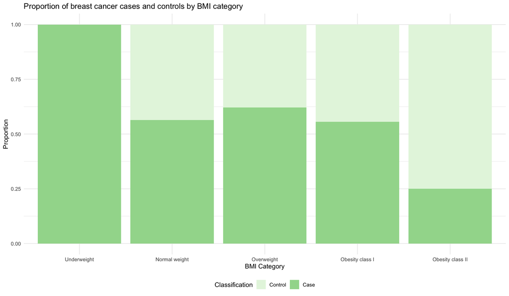

```r
bc_data = bc_data %>%
  mutate(BMI_cat = fct_reorder(BMI_cat, BMI),
         Classification = as.factor(case_when(Classification == 1 ~ "Control",
                                              Classification == 2 ~ "Case"))) %>%
  mutate(Classification = fct_relevel(Classification, "Control", "Case"))

BC_BMI = bc_data %>%
  group_by(BMI_cat, Classification) %>%
  summarise(N = n()) %>%
  mutate(Proportion = N/sum(N))

BC_BMI %>% ggplot(aes(x = BMI_cat, y = Proportion, fill = Classification)) +
  geom_bar(position = position_stack(reverse = F), stat = "identity") +
  labs(
    x = "BMI Category",
    y = "Proportion",
    title = "Proportion of breast cancer cases and controls by BMI category") +
  scale_fill_brewer(palette = "PiG")
```

## 4. Logistic regression model of breast cancer

The code below constructs a logistic regression model using breast cancer classification as the outcome and glucose, HOMA-IR, leptin, BMI (continuous) and age as the independent variables.

```r
fit_logistic = bc_data %>%
  glm(Classification ~ Glucose + HOMA + Leptin + BMI + Age, data = ., family = binomial())

fit_logistic %>%
  broom::tidy() %>%
  filter(term == "HOMA") %>%
  mutate(CIL = estimate - 1.96*std.error,
         CIU = estimate + 1.96*std.error) %>%
  select(term, estimate, CIL, CIU) %>%
  rename("Term" = term,
         "Beta estimate" = estimate) %>%
  knitr::kable(digits = 3)
```

| Term | Beta estimate | CIL | CIU |
| --- | --- | --- | --- |
| HOMA | 0.274 | -0.063 | 0.611 |

We can see that for a 1-unit increase in HOMA-IR, the log odds of having breast cancer is expected to increase by 0.274 (95% CI: -0.063, 0.611).

Next, we will construct a linear regression model using insulin as the outcome and BMI (continuous), age, and glucose as the independent variables.

```r
fit_linear = bc_data %>%
  lm(Insulin ~ BMI + Age + Glucose, data = .)

fit_linear %>%
  broom::tidy() %>%
  filter(term == "Age") %>%
  mutate(CIL = estimate - 1.96*std.error,
         CIU = estimate + 1.96*std.error) %>%
  select(term, estimate, CIL, CIU) %>%
  rename("Term" = term,
         "Beta estimate" = estimate) %>%
  knitr::kable(digits = 3)
```

| Term | Beta estimate | CIL | CIU |
| --- | --- | --- | --- |
| Age | -0.054 | -0.156 | 0.048 |